# Coursework Report

*N* removed NAs: 3

*N* removed typo: 1

*N* removed <18: 25

*N* total clean: 121

| Group | *N* | *M*<sub>age</sub> | *M*<sub>rating</sub> |
| --- | --- | --- | --- |
| Control | 61 | 20.7 | 5.36 |
| Experim | 60 | 20.6 | 6.38 |

**Main analysis results**

*t*(119) = -7.23, *p* < .001

[interactive chart not shown]

[figure not shown]

[interactive chart not shown]

# Coursework Report

Analysing Data, Spring 2020

# Methods

## Participants

Table 1: *Participant Descriptive Statistics by Condition*

| Condition | *n* | % | *M*<sub>age</sub> | *SD*<sub>age</sub> |
| --- | --- | --- | --- | --- |
| control | 61 | 50.4 | 20.7 | 2.07 |
| experimental | 60 | 49.6 | 20.6 | 1.95 |

## Design

The conceptual hypothesis for this study is the question of whether colour affects attractiveness. One variable used is id, which is a factor with one level, using four different letters to represent each participant. Another is group, which is a factor and represents the conditions in this study, where there were two levels. These were control (white background) and experimental (red background). A third variable was years which is a numeric rating which represents the participants’ ages. These ranged from 18 to 27. The other variables were item_1, item_2 and item_3 which are numeric ratings representing questions 1, 2 and 3 regarding the participants ratings of a male’s attractiveness. These questions were “How attractive do you think this person is?”, “How pleasant is this person to look at?” and “If I were to meet the person in this picture face to face, I would think he is attractive”. The answers represent a rating of attractiveness on a scale from 1-9, where the range of answers from item_1 and item_3 were 2-9, and the range from item_2 was 1-9. An answer of 1 meant “not at all attractive” and 9 meant “extremely attractive”. The operational hypothesis for this study is that women rate men more highly on attractiveness scales of 1-9 when a photo of a man is surrounded by a red border compared to when the photo is surrounded by a white border. An independent-measures *t*-test will be used to look at this.

# Results

This study involved investigating whether female participants would rate men as more attractive in conjunction with the colour red compared to white, using an independent-measures *t*-test. The *t*-test displayed that the means for the control and experimental conditions were different (*M*<sub>diff</sub> = -1.02, 95% CI [-1.3, -0.74]) and there was a significant difference between the two conditions regarding ratings of attractiveness in the red and white colour conditions (*t* (119) = -7.23, *p* < .001. Therefore the null hypothesis can be rejected. The graph below displays the mean attractiveness ratings. It shows that the mean attractiveness rating of all three questions for each condition was higher in the experimental condition than the control condition.

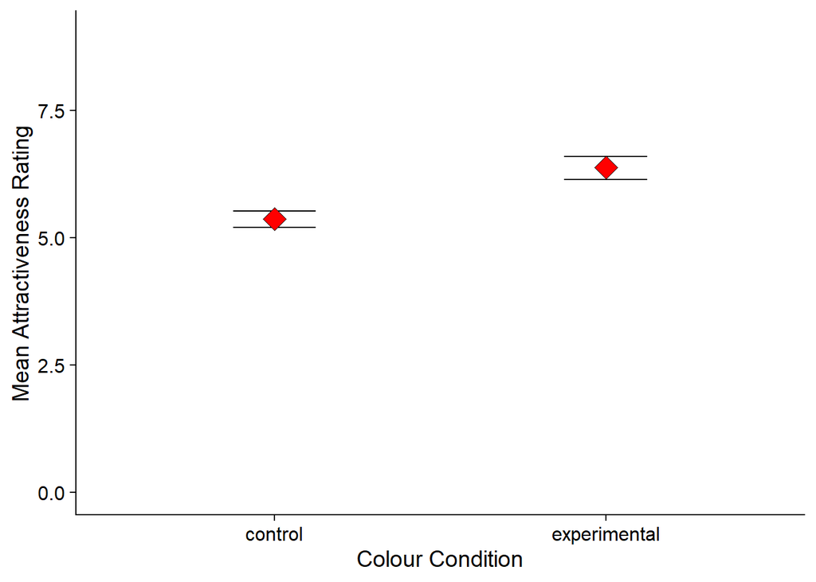

Table 2 displays that the mean attractiveness rating for each question asked was higher in the experimental condition than the control condition, illustrating this result.

Table 2: *Mean Attractiveness Ratings for each Question*

| Condition | *n* | Q1 mean | Q2 mean | Q3 mean |
| --- | --- | --- | --- | --- |
| control | 61 | 5.25 | 5.41 | 5.43 |
| experimental | 60 | 6.53 | 6.13 | 6.47 |

Meanwhile, table 3 illustrates that the overall mean of ratings for each condition - which include each of the three questions asked - is higher for the experimental condition than the control condition.

Table 3: *Mean Attractiveness Ratings for each Condition*

[output not shown]

The general pattern of results therefore suggests that women find men more attractive in conjunction with the colour red than the colour white, since the mean ratings are higher for the experimental group.

# Discussion

This study not only found results supporting the original study’s findings (Elliot et al, 2010), but also other experiments in this research area. The results support studies by both Pazda, Elliot & Greitemeyer (2014) and Roberts, Owen & Havlicek (2010) who found red to be associated with higher perceived sexual receptivity and higher attractiveness judgments. The findings of this study have implications in the relevant research area, where they support the supposed ‘red effect’ (Elliot et al, 2010) and therefore suggest that wider implications of such research being conducted exist. For example, these supportive findings further suggest that there may be implications with relevance to fashion, marketing and entertainment, where the effect of red on people may be used in certain ways that can benefit these industries (Elliot & Niesta, 2008). Further, implications exist surrounding relationships between men and women. Elliot & Niesta (2008) found that men saw women as more attractive and more sexually desirable in conjunction with the colour red, suggesting that the effect may exist both ways. A possible concern of such implications is the way that colour could be used in a way that is beneficial to an individual, such as in certain industries as mentioned previously but also in relationships.

Meanwhile, limitations of this study exist. The experiment has low ecological validity due to being conducted in a lab, meaning that the extent to which a ‘red effect’ can be applied to social situations and the wider context may be limited. There are strengths in the sense that this method provides higher internal validity regarding the results, yet the limitations regarding wider application may persist especially regarding implications such as those mentioned above.

Additionally, this study does not address other factors which may affect ratings of attractiveness. For example, it does not appear to consider the participants’ individual sexualities, partner preferences, or relationship statuses. Such factors may lead to the results not being as representative of the wider population since they may have interefered by encouraging participants to act in certain ways that others may not. This limits the extent we are able to comment on these findings with respect to important implications and suggests that more studies in this area need to be conducted in order for current research to be as beneficial as possible.

Regarding future research, there are some changes that can be made to gain the most out of conducting research in this area. Studies may want to control for more confounding variables in order to increase the validity of their findings, which will improve the likelihood that differences in the results are a result of the independent variable rather than factors that are unable to be controlled and may differ largely throughout the participants in the sample.

Meanwhile, this study and others (Elliot et al, 2010, Roberts et al 2010) have only looked at the effect of artificial illustrations of the colour red. Future research could look at red in the case of natural red, such as blushing in humans. This would be beneficial by looking more closely at the relationship between colour and attraction, as well as colour and human behaviour in general. A greater understanding of this relationship may provide benefits in a number of ways, such as regarding the implications previously mentioned.

The findings of this and other studies suggest that the red effect does exist, although more research needs to be conducted to look at the strength and extent of it. The fact that the ‘red effect’ appears to be a widely researched point with a number of conclusions of significant relationships suggests that there is a meaningful basis to it and that it exists at least in some form. However the extent of it remains unclear, displaying the importance of future research being carried out.

# References

Elliot, A. J., Niesta, D. (2008). Romantic red: Red enhances men’s attraction to women. Journal of Personality and Social Psychology, 95, 1150–1164. doi:10.1037/0022-3514.95.5.1150

Elliot, A. J., Niesta Kayser, D., Greitemeyer, T., Lichtenfeld, S., Gramzow, R. H., Maier, M. A., & Liu, H. (2010). Red, rank, and romance in women viewing men. Journal of Experimental Psychology: General, 139(3), 399–417. https://doi.org/10.1037/a0019689

Pazda, A. D., Elliot, A. J., Greitemeyer, T. (2014). Perceived sexual receptivity and fashionableness: Separate paths linking red and black to perceived attractiveness. Color Research & Application, 39, 208–212. doi:10.1002/col.21804

Roberts, S. C., Owen, R. C., Havlicek, J. (2010). Distinguishing between perceiver and wearer effects in clothing color-associated attributions. Evolutionary Psychology, 8, 350–364.